# “빅데이터 분석 결과 시각화 문제”

금경용

2021 2 17

## 문제 1. datasets::cars데이터 셋을 이용하여 속도에 대한 제동거리의 산점도와 적합도(신뢰구간 그래프)를 나타내시오(단, 속도가 5부터 20까지 제동거리 0부터 100까지만 그래프에 나타냄).

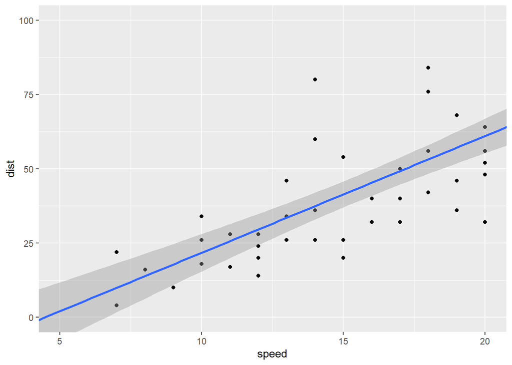

```r
library(ggplot2)
ggplot(cars, aes(x=speed, y=dist)) +
  geom_point() +
  geom_smooth(method="lm") +
  coord_cartesian(xlim=c(5, 20), ylim=c(0,100))
```

# 연습문제 2. gapminder::gapminder 데이터 셋을 이용하여 1인당국내총생산에 대한 기대수명의 산점도를 대륙별 다른 색으로 나타내시오.

```r
library(gapminder)
head(gapminder)
```

```
## # A tibble: 6 x 6
##   country     continent  year lifeExp      pop gdpPercap
##   <fct>       <fct>     <int>   <dbl>    <int>     <dbl>
## 1 Afghanistan Asia       1952    28.8  8425333      779.
## 2 Afghanistan Asia       1957    30.3  9240934      821.
## 3 Afghanistan Asia       1962    32.0 10267083      853.
## 4 Afghanistan Asia       1967    34.0 11537966      836.
## 5 Afghanistan Asia       1972    36.1 13079460      740.
## 6 Afghanistan Asia       1977    38.4 14880372      786.
```

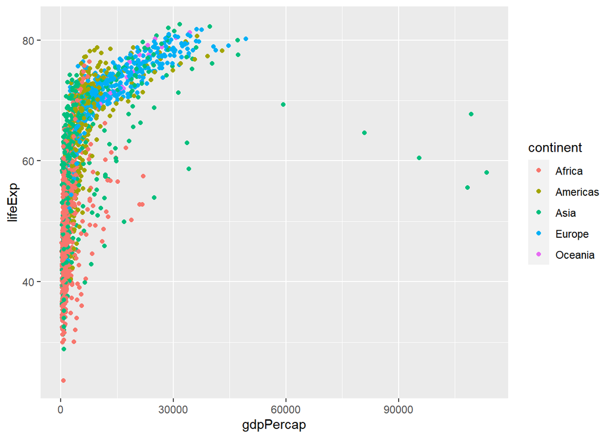

```r
ggplot(data=gapminder, aes(x=gdpPercap, y=lifeExp)) +
  geom_point(aes(col=continent))
```

# 연습문제 3. gapminder::gapminder 데이터 셋을 이용하여 개대 수명이 70을 초과하는 데이터에 대해 대륙별 데이터 갯수

```r
library(dplyr)
```

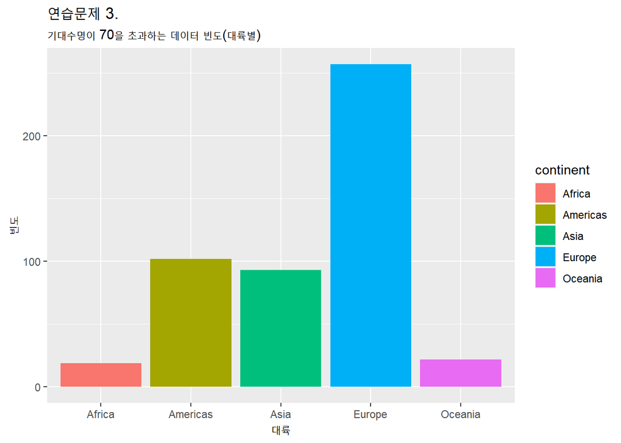

```r
gapminder %>%
  filter(lifeExp>70) %>%
  group_by(continent) %>%
  summarise(n = n()) %>%
  ggplot(aes(x=continent, y=n, fill=continent)) +
  geom_bar(stat = 'identity') +
  labs(title="연습문제 3.",
       subtitle="기대수명이 70을 초과하는 데이터 빈도(대륙별)",
       x ="대륙", y="빈도")
```

# 연습문제 4. gapminder::gapminder 데이터 셋을 이용하여 기대수명이 70을 초과하는 데이터에 대해 대륙별 나라 갯수.

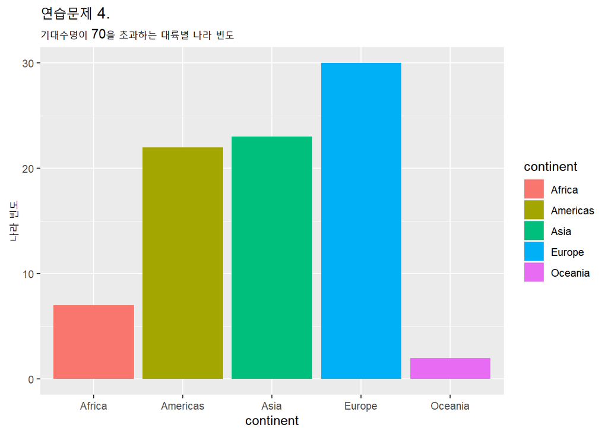

```r
gapminder %>%
  filter(lifeExp>70) %>%
  group_by(continent) %>%
  summarise(n = n_distinct(country)) %>%
  ggplot(aes(x=continent, y=n, fill=continent)) +
  geom_col() +
  labs(title="연습문제 4.",
       subtitle="기대수명이 70을 초과하는 대륙별 나라 빈도",  y="나라 빈도")
```

# 연습문제 5. gapminder::gapminder 데이터 셋을 이용하여 대륙별 기대수명의 사분위수를 시각화

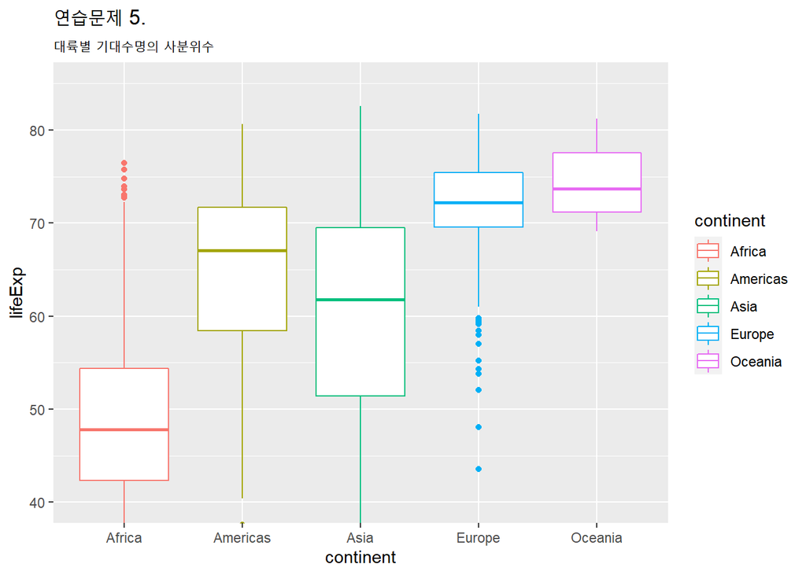

```r
ggplot(gapminder, aes(x=continent, y=lifeExp, col=continent)) +
  geom_boxplot() +
  coord_cartesian(ylim=c(40,85)) +
  labs(title="연습문제 5.",
       subtitle="대륙별 기대수명의 사분위수")
```

# 연습문제 6. gapminder::gapminder 데이터 셋을 이용하여 년도별로 gdp와 기대수명과의 관계를 산점도를 그리고 대륙별 점의 색상을 달리 시각화

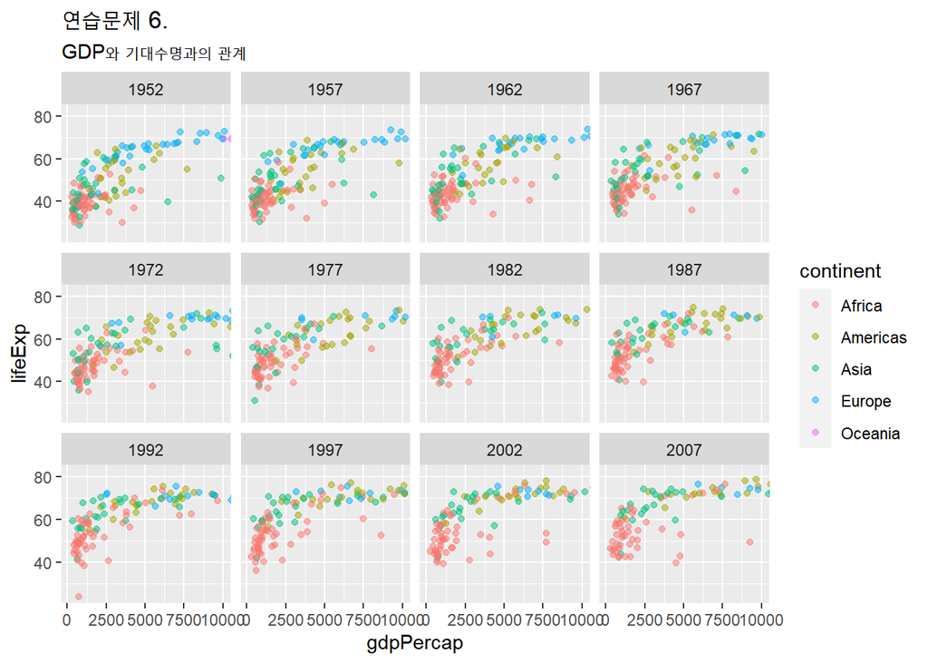

```r
ggplot(gapminder, aes(x=gdpPercap, y=lifeExp, col=continent))+
  geom_point(alpha=0.5)+
  facet_wrap(~year) +
  coord_cartesian(xlim=c(1e+02, 1e+04))+
  #scale_x_log10() +
  labs(title="연습문제 6.",
       subtitle="GDP와 기대수명과의 관계")
```

# 연습문제 7.gapminder::gapminder 데이터 셋에서 북한과 한국의 년도별 GDP 변화를 산점도로 시각화하시오(북한:Korea, Dem. Rep. 한국:Korea, Rep. substr(str, start, end)함수 이용)

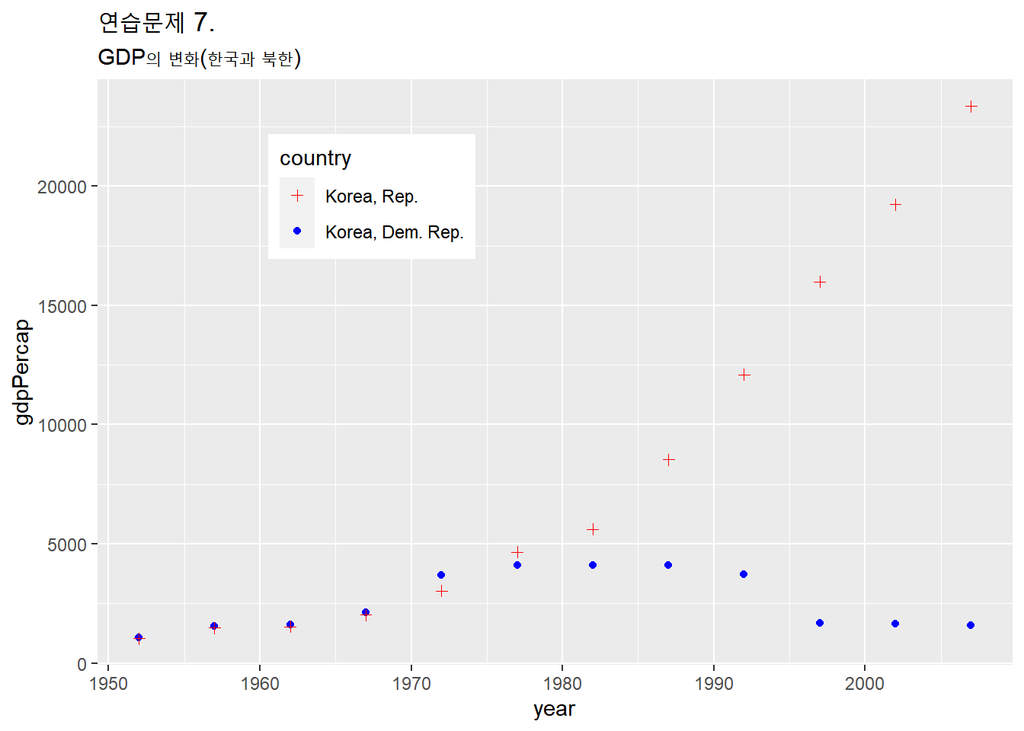

```r
temp <- gapminder %>%
  filter(substr(country,1,5)=='Korea')
temp$country <- factor(temp$country)
temp$country <- factor(temp$country, levels=c('Korea, Rep.','Korea, Dem. Rep.'))
ggplot(temp, aes(x=year, y=gdpPercap, col=country, shape=country))+ # shape==pch
  geom_point() +
  scale_shape_manual(values = c(3, 16)) +
  scale_color_manual(values = c('red','blue'))+
  labs(title="연습문제 7.",
       subtitle="GDP의 변화(한국과 북한)") +
  theme(legend.position = c(0.3, 0.8)) # 범례 없애고 싶으면 "none"
```

# 연습문제 8. gapminder::gapminder 데이터 셋을 이용하여 한중일 4개국별 GDP 변화를 산점도와 추세선으로 시각화 하시오.

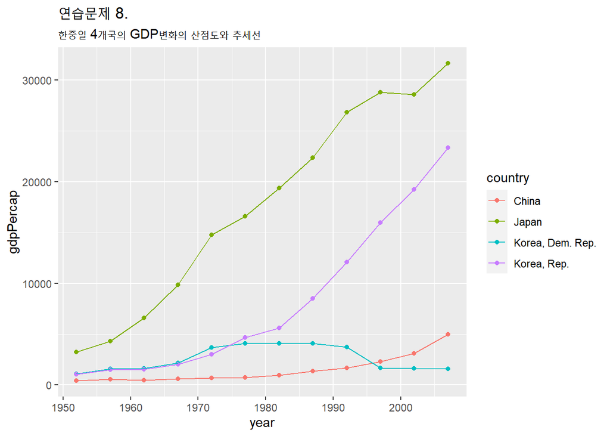

```r
gapminder %>%
  filter(substr(country,1,5)=='Korea' | country=='China' | country == 'Japan') %>%
  ggplot(aes(x=year, y=gdpPercap, col=country)) +
  geom_point() +
  geom_line() +
  labs(title="연습문제 8.",
       subtitle="한중일 4개국의 GDP변화의 산점도와 추세선")
```

# 연습문제 9. gapminder::gapminder 데이터 셋에서 한중일 4개국별 인구변화 변화를 산점도와 추세선으로 시각화 하시오(scale_y_continuous(labels = scales::comma)추가시 우측처럼)

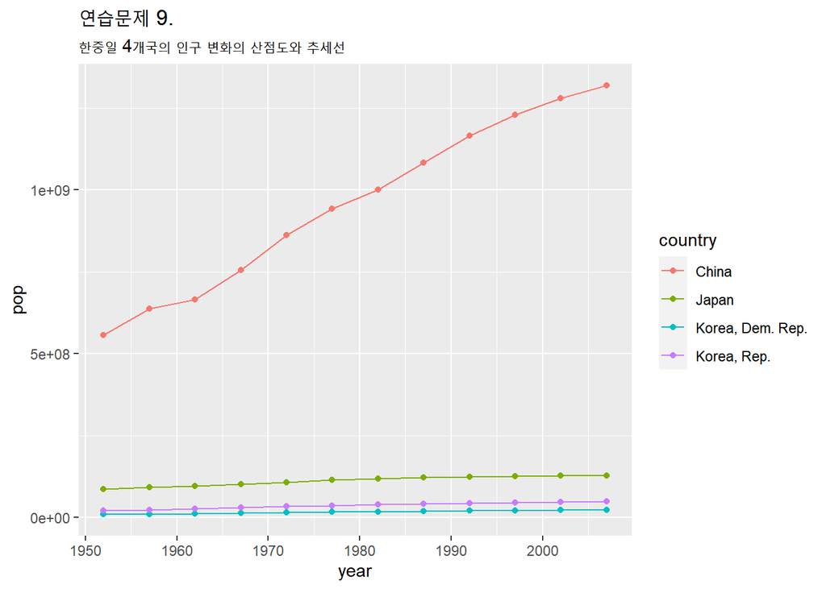

```r
gapminder %>%
  filter(substr(country,1,5)=='Korea' | country=='China' | country == 'Japan') %>%
  ggplot(aes(x=year, y=pop, col=country)) +
  geom_point() +
  geom_line() +
  labs(title="연습문제 9.",
       subtitle="한중일 4개국의 인구 변화의 산점도와 추세선")
```

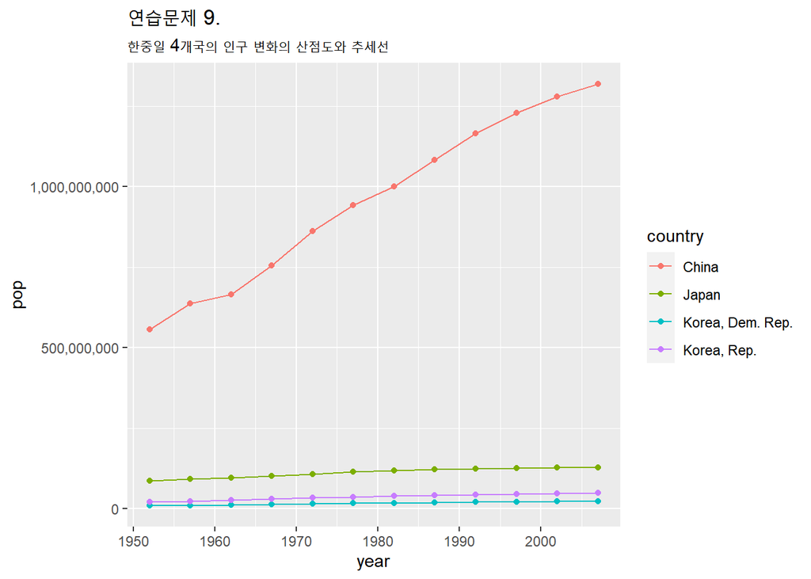

```r
gapminder %>%
  filter(substr(country,1,5)=='Korea' | country=='China' | country == 'Japan') %>%
  ggplot(aes(x=year, y=pop, col=country)) +
  geom_point() +
  geom_line() +
  labs(title="연습문제 9.",
       subtitle="한중일 4개국의 인구 변화의 산점도와 추세선") +
  scale_y_continuous(labels = scales::comma)
```

# 연습문제 10. Ggplot2::economic 데이터 셋의 개인 저축률(psavert)가 시간에 따라 어떻게 변해 왔는지 알아보려 한다. 시간에 따른 개인 저축률의 변화를 나타낸 시계열 그래프와 추세선을 시각화하시오

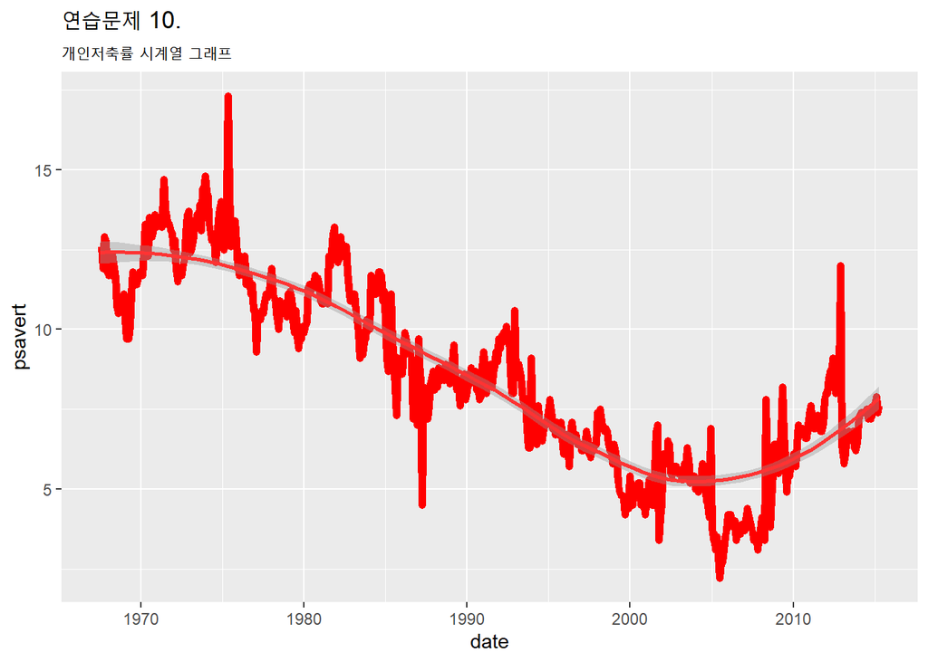

```r
ggplot(data=economics) +
  geom_line(aes(x=date, y=psavert), color="#FF0000", size=2) +
  geom_smooth(aes(x=date, y=psavert), col="#FF3333") +
  labs(title="연습문제 10.",
       subtitle="개인저축률 시계열 그래프")
```